# lab_3(2)

```python
import numpy as np
import pandas as pd
import matplotlib.pyplot as plt
import math
```

Пример 1. Даны точки P1,P2,P3. Осуществить перенос точек на 10 единиц вдоль оси ОХ

```python
P1=[ 1, 1 , 1]
P2=[10, 2 , 1]
P3=[20, 4 , 1]
P = np.array([P1,P2,P3])
print(P.shape)
T10x=np.array([[1, 0, 0],[0 ,1 ,0],[ 10, 0, 1]])
print(T10x)
P_new = np.dot(P,T10x)
P_new
```

```
(3, 3)
[[ 1  0  0]
 [ 0  1  0]
 [10  0  1]]
```

```
array([[11,  1,  1],
       [20,  2,  1],
       [30,  4,  1]])
```

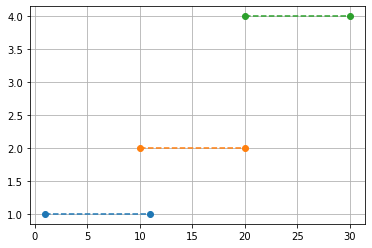

```python
for i in range(3):
    plt.plot([P[i,0], P_new[i,0]],[P[i,1],P_new[i,1]],'o--')
plt.grid()

plt.show()
```

Пример 2. Осуществить поворот точек на 10 градусов от начала координат Q=10/180*pi;

```python
Q=10/180*np.pi;
R=[[np.cos(Q), -np.sin(Q), 0],[np.sin(Q), np.cos(Q), 0],[0, 0, 1]]
R,Q
```

```
([[0.984807753012208, -0.17364817766693033, 0],
  [0.17364817766693033, 0.984807753012208, 0],
  [0, 0, 1]],
 0.17453292519943295)
```

```
[[ 1.15845593  0.81115958  1.        ]
 [10.19537389  0.23313373  1.        ]
 [20.39074777  0.46626746  1.        ]]
```

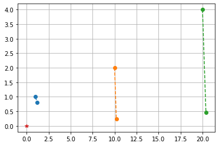

```python
P_new = np.dot(P,R)
print(P_new)
for i in range(3):
    plt.plot([P[i,0], P_new[i,0]],[P[i,1],P_new[i,1]],'o--')
plt.plot(0,0,'*')
plt.grid()
plt.show()
```

Поворот относительно произвольной точки выполняется как комбинация преобразований:

```
1. Перейти к произвольной точке xy:  T(-x,-y)
2. Повернуть на заданный угол : R(Q)
3. Вернуться из точки xy : T(x,y)
```

```
[[ 0.5        -0.8660254   0.        ]
 [ 0.8660254   0.5         0.        ]
 [-6.83012702  1.83012702  1.        ]]
[[ -5.46410162   1.46410162   1.        ]
 [ -0.09807621  -5.83012702   1.        ]
 [  6.6339746  -13.49038106   1.        ]]
```

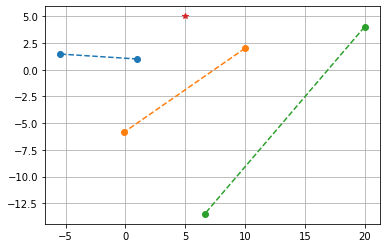

```python
P0 = [5,5,1]
Tp = np.array([[1, 0, 0],[0 ,1 ,0],[ -P0[0], -P0[1], 1]])

Q=60/180*np.pi;
R=[[np.cos(Q), -np.sin(Q), 0],[np.sin(Q), np.cos(Q), 0],[0, 0, 1]]

TR = np.dot(Tp,R)
print(TR)

P_new = np.dot(P,TR)
print(P_new)
for i in range(3):
    plt.plot([P[i,0], P_new[i,0]],[P[i,1],P_new[i,1]],'o--')
plt.plot(P0[0],P0[1],'*')
plt.grid()
plt.show()
```

Задание 1.

```
1. Осуществить построение точек по варианту (x1,y1)(x2,y2)(x3,y3)

2. Провести перенос точек по Тх,Ту

3. Провести поворот точек по Q (вывести на график, старое положение, новое положение и центр поворота)

4. Провести поворот точек на Q относительно хс,ус (вывести на график, старое положение, новое положение и центр поворота)
```

```python
P1=[ 0, -8 , 1]
P2=[0, -4 , 1]
P3=[0, 10 , 1]
P = np.array([P1,P2,P3])
print(P.shape)
T10x=np.array([[1, 0, 0],[0 ,1 ,0],[ 10, 2, 1]])
print(T10x)
P_new = np.dot(P,T10x)
P_new
```

```
(3, 3)
[[ 1  0  0]
 [ 0  1  0]
 [10  2  1]]
```

```
array([[10, -6,  1],
       [10, -2,  1],
       [10, 12,  1]])
```

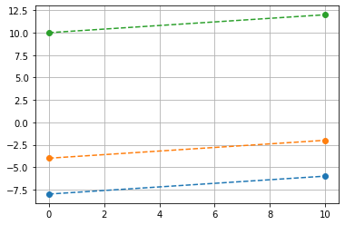

```python
for i in range(3):
    plt.plot([P[i,0], P_new[i,0]],[P[i,1],P_new[i,1]],'o--')

plt.grid()
plt.show()
```

```python
Q=-70/180*np.pi;
R=[[np.cos(Q), -np.sin(Q), 0],[np.sin(Q), np.cos(Q), 0],[0, 0, 1]]
R,Q
```

```
([[0.3420201433256688, 0.9396926207859083, 0],
  [-0.9396926207859083, 0.3420201433256688, 0],
  [0, 0, 1]],
 -1.2217304763960306)
```

```
[[ 7.51754097 -2.73616115  1.        ]
 [ 3.75877048 -1.36808057  1.        ]
 [-9.39692621  3.42020143  1.        ]]
```

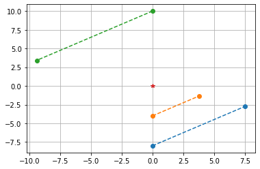

```python
P_new = np.dot(P,R)
print(P_new)
for i in range(3):
    plt.plot([P[i,0], P_new[i,0]],[P[i,1],P_new[i,1]],'o--')
plt.plot(0,0,'*')
plt.grid()
plt.show()
```

```
[[ 0.34202014  0.93969262  0.        ]
 [-0.93969262  0.34202014  0.        ]
 [ 7.98641217 12.59422138  1.        ]]
[[15.50395313  9.85806024  1.        ]
 [11.74518265 11.22614081  1.        ]
 [-1.41051404 16.01442282  1.        ]]
```

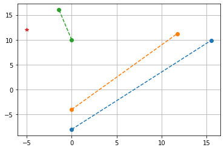

```python
P0 = [-5,12,1]
Tp = np.array([[1, 0, 0],[0 ,1 ,0],[ -P0[0], -P0[1], 1]])

Q=-70/180*np.pi;
R=[[np.cos(Q), -np.sin(Q), 0],[np.sin(Q), np.cos(Q), 0],[0, 0, 1]]

TR = np.dot(Tp,R)

Tp = np.array([[1, 0, 0],[0 ,1 ,0],[ P0[0], P0[1], 1]])
TR=np.dot(TR,Tp)
print(TR)

P_new = np.dot(P,TR)

print(P_new)
for i in range(3):
    plt.plot([P[i,0], P_new[i,0]],[P[i,1],P_new[i,1]],'o--')
plt.plot(P0[0],P0[1],'*')
plt.grid()
plt.show()
```

Задание 2.

[output not shown]

[output not shown]

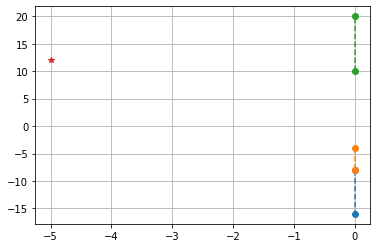

```python
P1=[ 0, -8 , 1]
P2=[0, -4 , 1]
P3=[0, 10 , 1]
P = np.array([P1,P2,P3])
print(TR)
S=np.array([[0.5, 0, 0],[0 ,2 ,0],[ 0, 0, 1]])
P_new = np.dot(P,S)
print(P_new)
for i in range(3):
    plt.plot([P[i,0], P_new[i,0]],[P[i,1],P_new[i,1]],'o--')
plt.plot(P0[0],P0[1],'*')
plt.grid()
plt.show()
```

[output not shown]

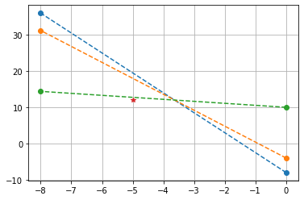

```python
P1=[ 0, -8 , 1]
P2=[0, -4 , 1]
P3=[0, 10 , 1]
P = np.array([P1,P2,P3])
print(TR)
P0=[-5,12,1]
Tm=np.array([[1, 0, 0],[0 ,1 ,0],[ -P0[0], -P0[1], 1]])
P_new = np.dot(P,Tm)

S=np.array([[-0.6, 0, 0],[0 ,-1.2 ,0],[ 0, 0, 1]])

P_new = np.dot(P_new,S)
Tm=np.array([[1, 0, 0],[0 ,1 ,0],[ P0[0], P0[1], 1]])
P_new = np.dot(P_new,Tm)
print(P_new)
for i in range(3):
    plt.plot([P[i,0], P_new[i,0]],[P[i,1],P_new[i,1]],'o--')
plt.plot(P0[0],P0[1],'*')
plt.grid()
plt.show()
```

Матрица преобразования T в общем случае имеет вид

```
          | A B C P|

          | D E F Q|

          | I J K R|

          | L M N S|
```

Подматрица 3×3 определяет суммарные смещение, масштабирование и поворот. Подматрица-строка 1×3 - [ L M N ] задает сдвиг. Подматрица-столбец 3×1 - [ P Q R ] отвечает за преобразование в перспективе. Последний скалярный элемент - S определяет общее изменение масштаба.

Преобразование систем координат:

Взаимная ортогональность столбцов матрицы поворота и их совмещение с осями координат при преобразовании, задаваемом матрицей, позволяет легко сконструировать матрицу преобразования, если известны его результаты. Пример. Формирование матрицы преобразования (из [1]) Пусть заданы три точки P1, P2, P3. Найти матрицу преобразования такого, что после преобразования вектор P1P2 будет направлен вдоль оси Z, а вектор P1P3 будет лежать в плоскости YZ.

```
1. Вначале надо сместить начало координат в точку P1 с помощью преобразования
```

```python
P1 = [ 1, 1 , 10, 1]
P2 = [10, 2 , 3, 1]
P3 = [20, 4 , 1, 1]





P0 = [1,1,10,1]

P = np.array([P1,P2,P3])
print(P.shape)

T=np.array([[1, 0, 0, 0],[0 ,1 ,0, 0],[0, 0, 1, 0],[  -P0[0], -P0[1],  -P0[2],1]])
print(T)
P_new = np.dot(P,T)
P_new
```

```
(3, 4)
[[  1   0   0   0]
 [  0   1   0   0]
 [  0   0   1   0]
 [ -1  -1 -10   1]]
```

```
array([[ 0,  0,  0,  1],
       [ 9,  1, -7,  1],
       [19,  3, -9,  1]])
```

```python
Rz=(P[0,:3]-P[1,:3])/(np.sum((P[0,:3]-P[1,:3])**2))**0.5
dz = (np.sum((Rz[:3])**2))**0.5
Rz = Rz/dz
Rz,dz
```

```
(array([-0.78633365, -0.08737041,  0.61159284]), 0.9999999999999999)
```

```python
d1 = (np.sum((P[0,:3]-P[1,:3])**2))**0.5
d2 = (np.sum((P[0,:3]-P[2,:3])**2))**0.5
RR = np.cross((P[0,:3]-P[1,:3])/d1,(P[0,:3]-P[2,:3])/d1)
Rx= RR
Rx
```

```
array([ 0.09160305, -0.39694656,  0.0610687 ])
```

```python
Ry=np.cross(Rx,Rz)
Ry
```

```
array([-0.23743408, -0.10404415, -0.32013584])
```

```python
R=np.array([Rx.tolist()+[0], Ry.tolist()+[0], Rz.tolist()+[0], [0 ,0, 0 ,1]]).T
R
```

```
array([[ 0.09160305, -0.23743408, -0.78633365,  0.        ],
       [-0.39694656, -0.10404415, -0.08737041,  0.        ],
       [ 0.0610687 , -0.32013584,  0.61159284,  0.        ],
       [ 0.        ,  0.        ,  0.        ,  1.        ]])
```

```python
M=np.dot(T,R)
M
```

```
array([[ 0.09160305, -0.23743408, -0.78633365,  0.        ],
       [-0.39694656, -0.10404415, -0.08737041,  0.        ],
       [ 0.0610687 , -0.32013584,  0.61159284,  0.        ],
       [-0.30534351,  3.5428366 , -5.24222434,  1.        ]])
```

```python
Rez = np.dot(P,M)
print(np.round(Rez,2))
```

```
[[  0.     0.     0.     1.  ]
 [ -0.     0.   -11.45   1.  ]
 [ -0.    -1.94 -20.71   1.  ]]
```

```python
Rez_ = np.eye(4, dtype = 'float')
Rez_[:,3] = 1.
print(Rez_)

Rez_M = np.dot(Rez_,M)
Rez_M
```

```
[[1. 0. 0. 1.]
 [0. 1. 0. 1.]
 [0. 0. 1. 1.]
 [0. 0. 0. 1.]]
```

```
array([[-0.21374046,  3.30540252, -6.02855799,  1.        ],
       [-0.70229008,  3.43879246, -5.32959475,  1.        ],
       [-0.24427481,  3.22270076, -4.6306315 ,  1.        ],
       [-0.30534351,  3.5428366 , -5.24222434,  1.        ]])
```

```python
RezZ = np.cross(Rez[1,:3]/(Rez[1,:3]**2).sum()**0.5,Rez[2,:3]/(Rez[2,:3]**2).sum()**0.5)
```

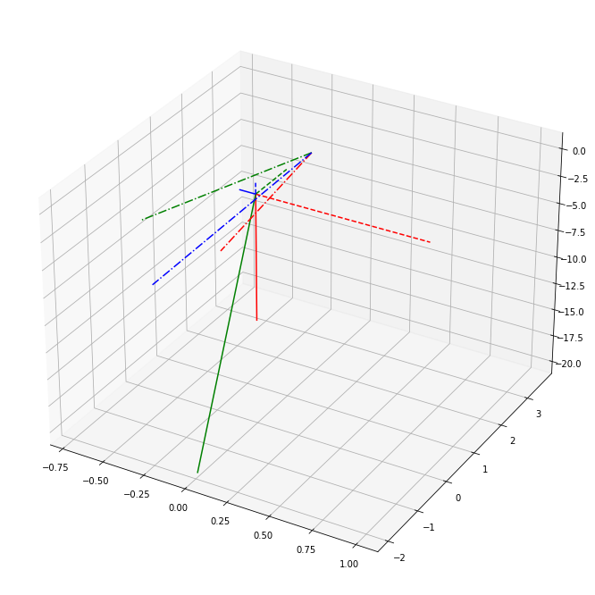

```python
fig = plt.figure(figsize=(12,12))
ax = plt.axes(projection='3d')
ax.plot3D([Rez[0,0] , Rez[1,0]], [Rez[0,1] , Rez[1,1]], [Rez[0,2] , Rez[1,2]], 'r')
ax.plot3D([Rez[0,0] , Rez[2,0]], [Rez[0,1] , Rez[2,1]], [Rez[0,2] , Rez[2,2]], 'g')
ax.plot3D([Rez[0,0] , RezZ[0]], [Rez[0,1] , RezZ[1]], [Rez[0,2] , RezZ[2]], 'b')

ax.plot3D([0 , 1], [0, 0] , [0,0], '--r')
ax.plot3D([0 , 0], [0, 1] , [0,0], '--g')
ax.plot3D([0 , 0], [0, 0] , [0,1], '--b')


ax.plot3D([Rez_M[3,0] , Rez_M[0,0]], [Rez_M[3,1] , Rez[0,1]], [Rez_M[3,2] , Rez_M[0,2]], '-.r')
ax.plot3D([Rez_M[3,0] , Rez_M[1,0]], [Rez_M[3,1] , Rez[1,1]], [Rez_M[3,2] , Rez_M[1,2]], '-.g')
ax.plot3D([Rez_M[3,0] , Rez_M[2,0]], [Rez_M[3,1] , Rez[2,1]], [Rez_M[3,2] , Rez_M[2,2]], '-.b')



plt.show()
```

```
[<mpl_toolkits.mplot3d.art3d.Line3D at 0x2d0b505d6d0>]
```

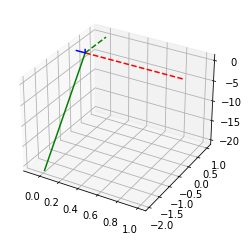

```python
fig = plt.figure()
ax = plt.axes(projection='3d')
ax.plot3D([0 , 1], [0, 0] , [0,0], '--r')
ax.plot3D([0 , 0], [0, 1] , [0,0], '--g')
ax.plot3D([0 , 0], [0, 0] , [0,1], '--b')
ax.plot3D([Rez[0,0] , Rez[2,0]], [Rez[0,1] , Rez[2,1]], [Rez[0,2] , Rez[2,2]], 'g')
ax.plot3D([Rez[0,0] , RezZ[0]], [Rez[0,1] , RezZ[1]], [Rez[0,2] , RezZ[2]], 'b')
```

Задание 3. Выполнить предшествующий пример

Задание 4. Построить точку x,y,z по варианту (см. в зад 1.)

```
1. Провести ее перенос на Tx,Ty,Tz по варианту (см. в зад 1.)

2. Провести поворот на Rx , Ry отдельно для каждого поворота и последовательно (показать результаты) по варианту (см. в зад 1.)


3. Провести поворот вокруг оси Z на Q по варианту (см. в зад 1.).


4. Провести поворот оси Z на Q по варианту (см. в зад 1.) относительно точки (5, -5, 5).

5. Отобразить все результаты и оценить различия.
```

```
(3, 4)
[[  1   0   0   0]
 [  0   1   0   0]
 [  0   0   1   0]
 [ -1  -1 -10   1]]
[[  0.     0.     0.     1.  ]
 [ -0.     0.   -11.45   1.  ]
 [ -0.    -1.94 -20.71   1.  ]]
[[1. 0. 0. 1.]
 [0. 1. 0. 1.]
 [0. 0. 1. 1.]
 [0. 0. 0. 1.]]
```

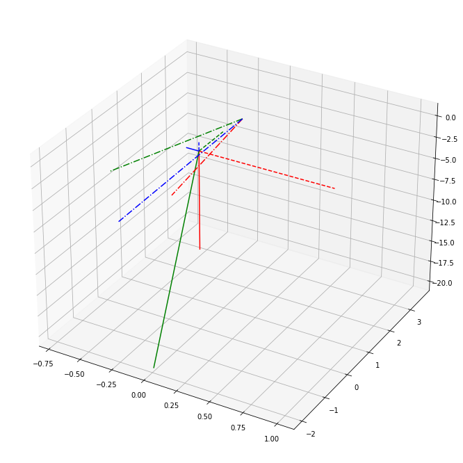

```python
P1 = [ 1, 1 , 10, 1]
P2 = [10, 2 , 3, 1]
P3 = [20, 4 , 1, 1]





P0 = [1,1,10,1]

P = np.array([P1,P2,P3])
print(P.shape)

T=np.array([[1, 0, 0, 0],[0 ,1 ,0, 0],[0, 0, 1, 0],[  -P0[0], -P0[1],  -P0[2],1]])
print(T)
P_new = np.dot(P,T)
P_new
Rz=(P[0,:3]-P[1,:3])/(np.sum((P[0,:3]-P[1,:3])**2))**0.5
dz = (np.sum((Rz[:3])**2))**0.5
Rz = Rz/dz
Rz,dz
d1 = (np.sum((P[0,:3]-P[1,:3])**2))**0.5
d2 = (np.sum((P[0,:3]-P[2,:3])**2))**0.5
RR = np.cross((P[0,:3]-P[1,:3])/d1,(P[0,:3]-P[2,:3])/d1)
Rx= RR
Rx
Ry=np.cross(Rx,Rz)
Ry
R=np.array([Rx.tolist()+[0], Ry.tolist()+[0], Rz.tolist()+[0], [0 ,0, 0 ,1]]).T
R
M=np.dot(T,R)
M
Rez = np.dot(P,M)
print(np.round(Rez,2))
Rez_ = np.eye(4, dtype = 'float')
Rez_[:,3] = 1.
print(Rez_)

Rez_M = np.dot(Rez_,M)
Rez_M
RezZ = np.cross(Rez[1,:3]/(Rez[1,:3]**2).sum()**0.5,Rez[2,:3]/(Rez[2,:3]**2).sum()**0.5)
fig = plt.figure(figsize=(12,12))
ax = plt.axes(projection='3d')
ax.plot3D([Rez[0,0] , Rez[1,0]], [Rez[0,1] , Rez[1,1]], [Rez[0,2] , Rez[1,2]], 'r')
ax.plot3D([Rez[0,0] , Rez[2,0]], [Rez[0,1] , Rez[2,1]], [Rez[0,2] , Rez[2,2]], 'g')
ax.plot3D([Rez[0,0] , RezZ[0]], [Rez[0,1] , RezZ[1]], [Rez[0,2] , RezZ[2]], 'b')

ax.plot3D([0 , 1], [0, 0] , [0,0], '--r')
ax.plot3D([0 , 0], [0, 1] , [0,0], '--g')
ax.plot3D([0 , 0], [0, 0] , [0,1], '--b')


ax.plot3D([Rez_M[3,0] , Rez_M[0,0]], [Rez_M[3,1] , Rez[0,1]], [Rez_M[3,2] , Rez_M[0,2]], '-.r')
ax.plot3D([Rez_M[3,0] , Rez_M[1,0]], [Rez_M[3,1] , Rez[1,1]], [Rez_M[3,2] , Rez_M[1,2]], '-.g')
ax.plot3D([Rez_M[3,0] , Rez_M[2,0]], [Rez_M[3,1] , Rez[2,1]], [Rez_M[3,2] , Rez_M[2,2]], '-.b')



plt.show()
```

```
[[-5 10  4  1]]
[[-2 16 -6  1]]
```

```
[<mpl_toolkits.mplot3d.art3d.Line3D at 0x2d0b4ad3730>]
```

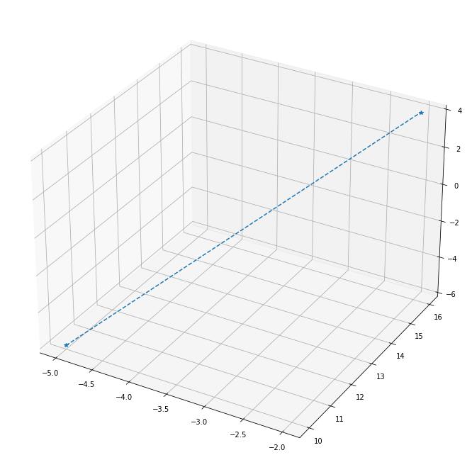

```python
P3 = [-5, 10 , 4, 1]





P0 = [-3, -6 , 10, 1]

P = np.array([P3])
print(P)

T=np.array([[1, 0, 0, 0],[0 ,1 ,0, 0],[0, 0, 1, 0],[  -P0[0], -P0[1],  -P0[2],1]])

P_new = np.dot(P,T)
print(P_new)

fig = plt.figure(figsize=(12,12))
ax = plt.axes(projection='3d')
ax.plot3D([P[0,0] ,P_new[0,0]],[ P[0,1] , P_new[0,1]],[P_new[0,2],P[0,2]], '--*')
```

```
[-4.04785021 10.76500678 -2.95457911  1.        ]
```

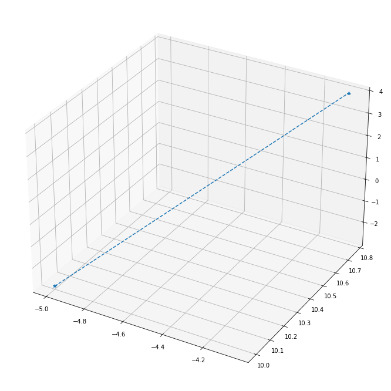

```python
P3 = np.array([-5, 10 , 4, 1])
cosx = math.cos(math.radians(20))
sinx=math.sin(math.radians(20))
cosy=math.cos(math.radians(-40))
siny=math.sin(math.radians(-40))
Rx=np.array([[1, 0, 0, 0],[0 ,cosx ,sinx, 0],[0, -sinx, cosx, 0],[  0, 0,  0,1]])
Ry=np.array([[cosy, 0, -siny, 0],[0 ,1 ,0, 0],[siny, 0, cosy, 0],[  0, 0,  0,1]])
P_new=np.dot(np.dot(Rx,P3),Ry)
print(P_new)
fig = plt.figure(figsize=(12,12))
ax = plt.axes(projection='3d')
ax.plot3D([P3[0] ,P_new[0]],[ P3[1] , P_new[1]],[P_new[2],P3[2]], '--*')

plt.show()
```

```
[-11.10702692  -1.27826167   4.           1.        ]
```

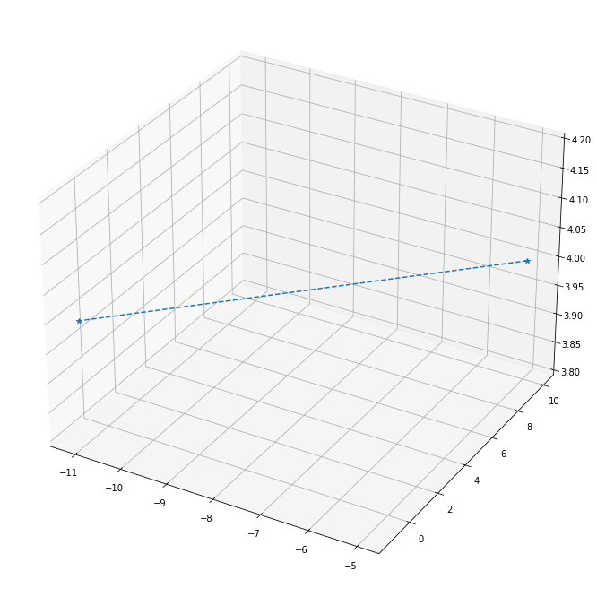

```python
P3 = np.array([-5, 10 , 4, 1])
cosz=math.cos(math.radians(-70))
sinz=math.sin(math.radians(-70))
Rz=np.array([[cosz, sinz, 0, 0],[-sinz ,cosz ,0, 0],[0, 0, 1, 0],[  0, 0,  0,1]])

P_new=np.dot(Rz,P3)
print(P_new)
fig = plt.figure(figsize=(12,12))
ax = plt.axes(projection='3d')
ax.plot3D([P3[0] ,P_new[0]],[ P3[1] , P_new[1]],[P3[2],P_new[2]], '--*')

plt.show()
```

```
[[ 0.34202014  0.93969262  0.          0.        ]
 [-0.93969262  0.34202014  0.          0.        ]
 [ 0.          0.          1.          0.        ]
 [-1.40856382 -7.98836239  0.          1.        ]]
[-12.51559075  -9.26662406   4.           1.        ]
```

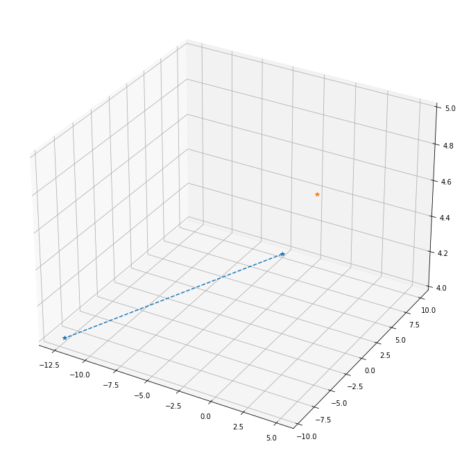

```python
P3 = np.array([-5, 10 , 4, 1])
P0 = [5,-5,5,1]
Tp = np.array([[1, 0, 0,0],[0 ,1 ,0,0],[0,0,1,0],[ -P0[0],-P0[1],-P0[2] , 1]])

Q=-70/180*np.pi;
R=[[np.cos(Q), -np.sin(Q), 0,0],[np.sin(Q), np.cos(Q), 0,0],[0, 0, 1,0],[0,0,0,1]]

TR = np.dot(Tp,R)
Tp = np.array([[1, 0, 0,0],[0 ,1 ,0,0],[0,0,1,0],[ P0[0],P0[1],P0[2] , 1]])
TR = np.dot(TR,Tp)
print(TR)

P_new = np.dot(P3,TR)
print(P_new)
fig = plt.figure(figsize=(12,12))
ax = plt.axes(projection='3d')
ax.plot3D([P3[0] ,P_new[0]],[ P3[1] , P_new[1]],[P3[2],P_new[2]], '--*')
ax.plot3D(P0[0],P0[1],P0[2], '*')
plt.show()
```

Задание 5

Построить трехмерное изображение каркасной модели фигуры по -варианту :

- используем преобразования для получения координат точек. Например, для построения 2D окружности вокруг начала кординат используем код в стиле :

```
[[ 5.00000000e+00  1.11022302e-16  7.07106781e+00  1.00000000e+00]
 [ 5.00000000e+00  7.07106781e+00  1.11022302e-16  1.00000000e+00]
 [-5.00000000e+00  7.07106781e+00  1.11022302e-16  1.00000000e+00]
 [-5.00000000e+00  1.11022302e-16  7.07106781e+00  1.00000000e+00]]
```

```
[<mpl_toolkits.mplot3d.art3d.Line3D at 0x1955eeb6460>]
```

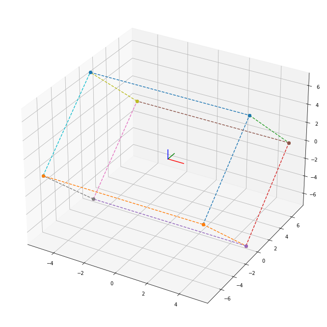

```python
a=10
P1 = [a,0,0,1]
P2 = [a,a,0,1]
P3 = [0,a,0,1]
P4 = [0,0,0,1]
P0=[0,0,10]
P = np.array([P1,P2,P3,P4])
Tp = np.array([[1, 0, 0,0],[0 ,1 ,0,0],[0,0,1,0],[ P0[0],P0[1],P0[2] , 1]])
Q=-45/180*np.pi;
Rx=[[1, 0, 0,0],[0, np.cos(Q), np.sin(Q),0],[0, -np.sin(Q), np.cos(Q),0],[0,0,0,1]]
Q=-90/180*np.pi;
Ry=[[np.cos(Q), 0, -np.sin(Q),0],[0, 0, 0,0],[np.sin(Q), 0, np.cos(Q),0],[0,0,0,1]]
P_new=np.dot(P,Tp)
P0=[-5,-5,-5]
Tp = np.array([[1, 0, 0,0],[0 ,1 ,0,0],[0,0,1,0],[ P0[0],P0[1],P0[2] , 1]])
P=np.dot(P,Tp)
P_new=np.dot(P_new,Tp)
P_new=np.dot(P_new,Rx)
P=np.dot(P,Rx)
print ( P_new)
fig = plt.figure(figsize=(12,12))
ax = plt.axes(projection='3d')
for i in range(4):
    ax.plot3D([P[i,0],P_new[i,0]],[P[i,1],P_new[i,1]],[P[i,2], P_new[i,2]],'o--')
    if i<3:
        ax.plot3D([P[i,0],P[i+1,0]],[P[i,1],P[i+1,1]],[P[i,2], P[i+1,2]],'o--')
    if i<3:
        ax.plot3D([P_new[i,0],P_new[i+1,0]],[P_new[i,1],P_new[i+1,1]],[P_new[i,2], P_new[i+1,2]],'o--')
ax.plot3D([P_new[3,0],P_new[0,0]],[P_new[3,1],P_new[0,1]],[P_new[3,2], P_new[0,2]],'o--')
ax.plot3D([P[3,0],P[0,0]],[P[3,1],P[0,1]],[P[3,2], P[0,2]],'o--')

ax.plot3D([0 , 1], [0, 0] , [0,0], 'r')
ax.plot3D([0 , 0], [0, 1] , [0,0], 'g')
ax.plot3D([0 , 0], [0, 0] , [0,1], 'b')
```

```python
alf = 10/180*np.pi#  угол между соседними точками окружности
r = 10 # circle radius
R = [[np.cos(alf), np.sin(alf) ,0],[-np.sin(alf), np.cos(alf), 0], [0, 0, 1]]

p0 = [r ,0, 1]
P = [p0]
for  n in np.linspace( 0,360, 360 // 10):
  P += [np.dot(P[-1][:],R).tolist()]

P = np.array(P)
plt.plot(P[:,0],P[:,1])
plt.grid()
plt.show()
```

[output not shown]

[output not shown]

```
• сделать визуализацию результата
```

Вариант

1 Куб с ребром 10 и центром в начале координат, грани параллельны основным плоскостям

2 Куб с ребром 10 и центром в начале координат, главная диагональ лежит на оси OZ

3 Построить призму с осью вдоль OZ, основание в плоскости ХОУ Радиусом 10 и 6-ю гранями

4 Построить пирамиду с осью вдоль OZ, вершиной в точке 0,0, 10 Радиусом 10 и 6-ю гранями

Функции аффинных преобразований

Примеры манипуляций в 3Д:

https://jenyay.net/Programming/Python3d

https://habr.com/ru/post/572760/

```python
#import matplotlib
from matplotlib import pyplot as plt
from mpl_toolkits import mplot3d


def plot_verticles(vertices, isosurf = False, filename = None):
    # Create a new plot
    fig = plt.figure()
    ax = fig.add_subplot(111, projection='3d')
    x = [v[0] for v in vertices]
    y = [v[1] for v in vertices]
    z = [v[2] for v in vertices]
    if isosurf:
        ax.plot_trisurf(x, y, z, linewidth=0.2, antialiased=True)
    else:
        ax.scatter(x, y, z, c='r', marker='o')
    ax.set_xlabel('X')
    ax.set_ylabel('Y')
    ax.set_zlabel('Z')
    # Show or save the plot
    if filename is None:
        plt.show()
    else:
        plt.savefig(filename)


def plot_mesh(
    your_mesh,
    size_x=10,
    size_y=10,
    dpi=80,
    filename = None
    ):
    # Create a new plot
    figure = plt.figure(figsize=(size_x, size_y), dpi=dpi)
    #axes = mplot3d.Axes3D(figure, auto_add_to_figure=False)
    axes = mplot3d.Axes3D(figure)
    axes.add_collection3d(mplot3d.art3d.Poly3DCollection(your_mesh.vectors, edgecolor="black"))
    figure.add_axes(axes)
    # Auto scale to the mesh size
    scale = your_mesh.points.flatten()
    axes.auto_scale_xyz(scale, scale, scale)
    # Show or save the plot
    if filename is None:
        plt.show()
    else:
        #matplotlib.use('Agg')
        plt.savefig(filename)
```

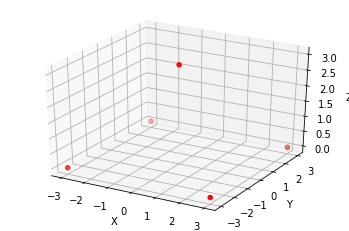

```python
vertices = np.array(
    [
        [-3, -3, 0],
        [+3, -3, 0],
        [+3, +3, 0],
        [-3, +3, 0],
        [+0, +0, +3]
    ]
)
plot_verticles(vertices = vertices, isosurf = False)
```

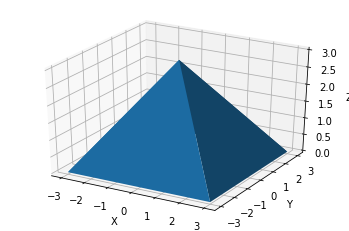

```python
plot_verticles(vertices = vertices, isosurf = True)
```

```python
X, Y = np.meshgrid([1,2,3], [4,5,6,7])
X,Y
```

```
(array([[1, 2, 3],
        [1, 2, 3],
        [1, 2, 3],
        [1, 2, 3]]), array([[4, 4, 4],
        [5, 5, 5],
        [6, 6, 6],
        [7, 7, 7]]))
```

```python
def makeData ():
    # Строим сетку в интервале от -10 до 10, имеющую 100 отсчетов по обоим координатам
    x = np.linspace (-10, 10, 100)
    y = np.linspace (-10, 10, 100)

    # Создаем двумерную матрицу-сетку
    xgrid, ygrid = np.meshgrid(x, y)

    # В узлах рассчитываем значение функции
    z = np.sin (xgrid) * np.sin (ygrid) / (xgrid * ygrid)
    return xgrid, ygrid, z
```

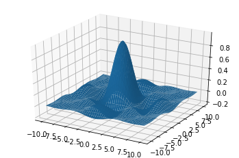

```python
if 1:
    x, y, z = makeData()

    fig = plt.figure()
    axes = fig.add_subplot(projection='3d')

    # !!!
    axes.plot_surface(x, y, z)

    plt.show()
```

```python
XYZ = [x.reshape(-1),y.reshape(-1),z.reshape(-1),np.ones(x.size).reshape(-1)]
XYZ = np.array(XYZ).T


alf = 3/180*np.pi#  угол между соседними точками окружности

R = [[np.cos(alf),0 , np.sin(alf) ,0],[0,1,0,0],[-np.sin(alf), 0., np.cos(alf), 0.], [0.,0,0,1.]]


XYZ = np.dot(XYZ,R)
XYZ[:2,:]
```

```
array([[ -9.98645024, -10.        ,  -0.52040403,   1.        ],
       [ -9.78465796, -10.        ,  -0.51076503,   1.        ]])
```

```python
x1 = XYZ[:,0].reshape(x.shape)
y1 = XYZ[:,1].reshape(y.shape)
z1 = XYZ[:,2].reshape(z.shape)
```

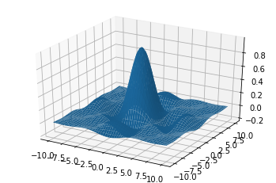

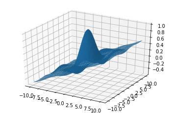

```python
if 1:
    fig = plt.figure()
    axes = fig.add_subplot(projection='3d')

    # !!!
    axes.plot_surface(x, y, z)

    plt.show()

if 1:
    fig = plt.figure()
    axes = fig.add_subplot(projection='3d')

    # !!!
    axes.plot_surface(x1, y1, z1)

    plt.show()
```